# IBGE 1

Farei aqui reproduções das análises do Guto usando o notebook do R.

Pois é, o R também tem notebook que podem facilmente criar arquivos em PDF, HTML e DOC.

Adeus editor de texto. Se o seu texto é um relatório que envolve análise de dados, é muito melhor fazer por aqui.

Aqui vai a reprodução da análise IBGE 1.

Primeiramente abrimos os dados baixados do site do IBGE, conforme explicado pelo Guto. Pode ser qualquer arquivo. O meu foi IMB201009.txt. Vamos guardar o arquivo na variável `dados`, que é do tipo `dataframe`.

```r
dados = read.csv2(
   "/home/mauricio/Dropbox/Projetos/Programacao em Python e R - 2021/Analise Dados/IBGE1/IMB201009.txt",
   header=FALSE,
   sep="")
```

Para ver os dados use `View(dados)` ou `print(dados)`.

Os nomes das colunas (V1 a V4) foram dados automaticamente.

Agora vamos executar os códigos para gerar um gráfico:

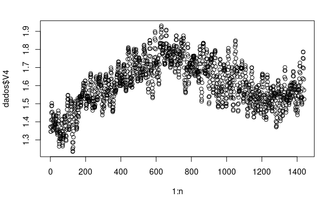

```r
n=length(dados$V4)      #Número de linhas de V4
plot(1:n,                 #Plota x e y
   dados$V4)
```

Vamos plotar do novo mudando algumas características do gráfico.

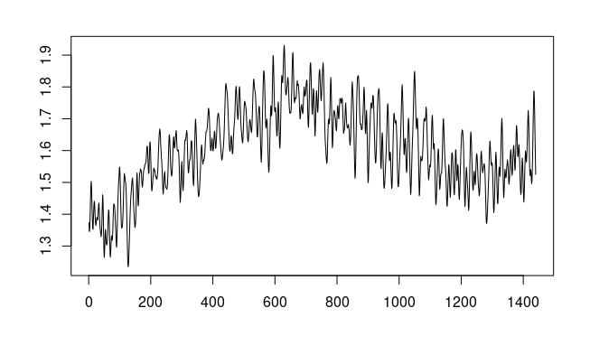

```r
plot(1:n,               #Plota novamente em linha
   dados$V4,
   type='line',
   xlab='',ylab='')
```

Agora vamos ajeitar o eixo x (tempo), que ainda não é do tipo datetime. Primeiro concatenamos as duas colunas de Data e Hora e depois transformamos para o tipo datetime.

```r
tempo=paste(dados$V1,dados$V2)
tempo=as.POSIXct(tempo,format = "%d/%m/%Y %H:%M:%S")
```

Cria o plot completo contendo a série V3 em azul e V4 em vermelho.

```r
plot(tempo,                #Eixo x
     dados$V3,             #Eixo y
     type='line',          #Tipo de linha
     col='blue',           #Cor da linha
     main='IMB201009.txt',  #Título do gráfico
     ylab='Nível (m)',     #Título do eixo y
     xlab='Tempo')         #Título do eixo x
lines(tempo,         #Adiciona nova série (V4) em vermelho
      dados$V4,
      type='line',
      col='red')
```

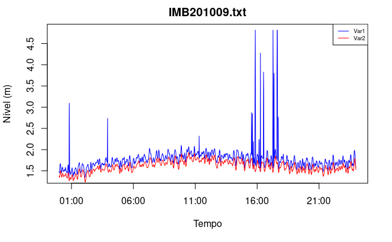

```r
legend('topright',  #Adiciona legenda
       legend=c('Var1','Var2'),
       lty=c(1,1),
       col=c('blue','red'),
       cex=0.6)
```